# Day34–ChiSquareIV : Practice

## Today’s Agenda

- Chi-Square tests can be used in three ways:
  - indpenedence of variables
  - goodness of fit
  - homogeneity
- In every case you want to compute the chi-squared statistic:

$$\chi^2 = \sum
\frac{(\text{observed}-\text{expected})^2}{\text{expected}}$$

- In a goodness of fit test you KNOW the expected values.
- For example:
  - is rolling a die uniform?
  - does a roulette table seem fair?
  - do your data match expectations from a population?
- In a test of homogeneity you you don’t exactly know the expected values, you need to calculate them.
- For example;
  - do North Carolinians and Californians have the same distribution of TVs in their homes (we don’t know the distribution, we are just asking if the are similar)?
  - is distribution of amount of time spent on the computer per day the same between apple and android users?

Compare and contrast the two questions:

Below is a table describing average amount of time spent on the computer in two groups:

| Avg. Hours per day | Group A | Group B |
| --- | --- | --- |
| $<1$ hour | $30$ | $26$ |
| $1-3$ hours | $35$ | $42$ |
| $3-5$ hours | $25$ | $22$ |
| $>5$ hours | $10$ | $10$ |
| Totals |  | $100$ |

1. If Group A is apple users and Group B is windows users, do the data provide evidence that the groups follow different distributions?

$H_0:$ they are homogeneous ( both data come from the same or similar distributions) $H_A:$ they are not homogeneous (the data seem to come from different distributions)

```r
#This is a test of homogeneity, we want to know if A and B come from the same distribution.
e_11 <- 56*100/200
e_12 <- 56*100/200
e_21 <- 77*100/200
e_22 <- 77*100/200
e_31 <- 47*100/200
e_32 <- 47*100/200
e_41 <- 20*100/200
e_42 <- 20*100/200
chi <- (30-e_11)^2/e_11 + (26-e_12)^2/e_12 + (35-e_21)^2/e_21 + (42-e_22)^2/e_22 + (25-e_31)^2/e_31 + (22-e_32)^2/e_32 + (10-e_41)^2/e_41 + (10-e_42)^2/e_42

# Our data does not provide statistically significant evidence that the distributions are different from one another.
```

2. If Group A is apple users and Group B is the expected percentage in the entire population, do the data provide evidence that the group A does not follow the expected distribution?

```r
# Goodness of fit test, we want to know if group A matches the expected distribution which is group B

chi <- (30-26)^2/26 + (35-42)^2/42 + (25-22)^2/22 + (10-10)^2/10

# This data does not provide statistically significant evidence that apple users are different than the expected distribution
```

## Recap of three test

- Test of independence
  - the null is always that two variables are independent of each other (think grade level and what they found important)
  - the alternate is always that the two variables are dependent
  - the expected values are always row total * column total / overall total
  - dof are (# of rows -1) * (# of columns -1 )
- Test of homogeneity
  - the null is always that two distributions match each other
  - the alternate is always that the two distributions are different
  - the expected values are always row total * column total / overall total
  - dof are (# of rows -1) * (# of columns -1 )
- Goodness of fit test
  - null is that the data matches an expected distribution
  - alternate is that it doesn’t
  - expected values are always given to you
  - dof are number of bins - 1

## Correlation

For the following section we will use data from: “Learning Statistics with R” by Danielle Navarro:

```r
load("~/MAT104-Spring25/Week12/parenthood.Rdata")
load("~/MAT104-Spring25/Week12/pearson_correlations.RData")
load("~/MAT104-Spring25/Week12/effort.Rdata")
```

- This data captures how grumpy Danielle is, how much she slept in a day, and how much her baby slept in a day.

Consider the following plots:

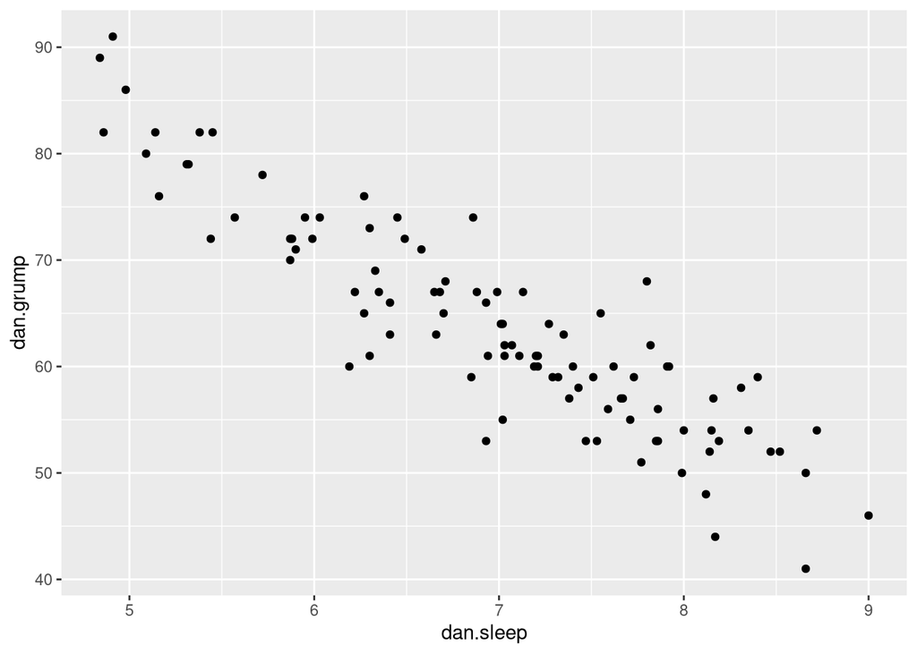

```r
ggplot(parenthood, aes(x=dan.sleep, y=dan.grump)) + geom_point()
```

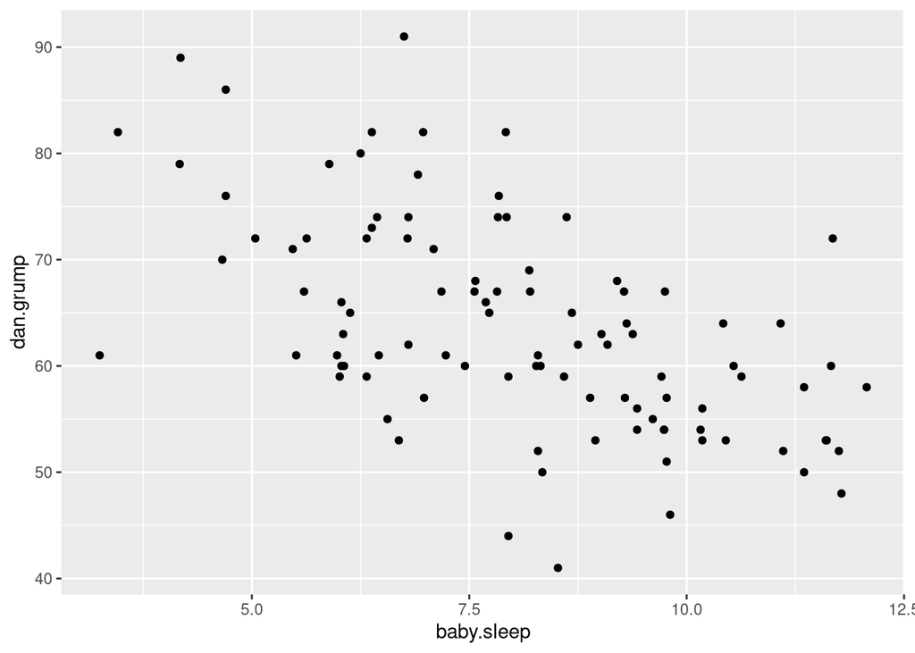

```r
ggplot(parenthood, aes(x=baby.sleep, y=dan.grump)) + geom_point()
```

## Correlation coefficient

The Pearson correlation coefficient $r_{XY}$ is a standardized covariance measure:

$$r_{XY} = \frac{1}{N-1} \sum_{i=1}^{N}
\frac{X_i-\bar{X}}{s_X}\frac{Y_i-\bar{Y}}{s_Y}$$

where $s_x$ and $s_y$ are the sample standard deviations.

### Interpreting the Pearson correlation coefficient

Below is data with various Pearson correlation coefficients:

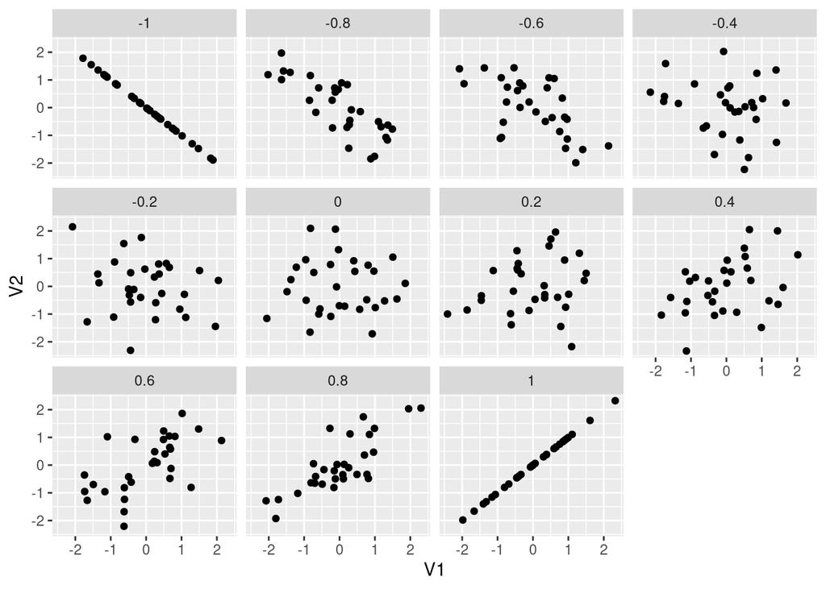

```r
ggplot(outcomes, aes(x=V1,y=V2))+geom_point() + facet_wrap(~pearson)
```

- Exactly what constitutes as a strong correlation depends on the context.
- You can, however, use these general guidlines:

| Correlation | Strength | Direction |
| --- | --- | --- |
| $-1$ to $-0.9$ | Very Strong | Negative |
| $-0.9$ to $-0.7$ | Strong | Negative |
| $-0.7$ to $-0.4$ | Moderate | Negative |
| $-0.4$ to $-0.2$ | Weak | Negative |
| $-0.2$ to $0$ | Negligible | Negative |
| $0$ to $0.2$ | Negligible | Positive |
| $0.2$ to $0.4$ | Weak | Positive |
| $0.4$ to $0.7$ | Moderate | Positive |
| $0.7$ to $0.9$ | Strong | Positive |
| $0.9$ to $1$ | Very Strong | Positive |